#Downloads necessary packages for Assignment #1.

#Reads files into R as CSVs and stacks them together, for electricity and for gas.

```
## [1] "PGE_A1/CSVs/PGE_2017_Q1_ElectricUsageByZip.csv"
## [1] "PGE_A1/CSVs/PGE_2017_Q1_GasUsageByZip.csv"
## [1] "PGE_A1/CSVs/PGE_2017_Q2_ElectricUsageByZip.csv"
## [1] "PGE_A1/CSVs/PGE_2017_Q2_GasUsageByZip.csv"
## [1] "PGE_A1/CSVs/PGE_2017_Q3_ElectricUsageByZip.csv"
## [1] "PGE_A1/CSVs/PGE_2017_Q3_GasUsageByZip.csv"
## [1] "PGE_A1/CSVs/PGE_2017_Q4_ElectricUsageByZip.csv"
## [1] "PGE_A1/CSVs/PGE_2018_Q1_ElectricUsageByZip.csv"
## [1] "PGE_A1/CSVs/PGE_2018_Q1_GasUsageByZip.csv"
## [1] "PGE_A1/CSVs/PGE_2018_Q2_ElectricUsageByZip.csv"
## [1] "PGE_A1/CSVs/PGE_2018_Q2_GasUsageByZip.csv"
## [1] "PGE_A1/CSVs/PGE_2018_Q3_ElectricUsageByZip.csv"
## [1] "PGE_A1/CSVs/PGE_2018_Q3_GasUsageByZip.csv"
## [1] "PGE_A1/CSVs/PGE_2018_Q4_ElectricUsageByZip.csv"
## [1] "PGE_A1/CSVs/PGE_2018_Q4_GasUsageByZip.csv"
```

[output cut: 22 more lines]

# Filters through the files for data on residential and commercial electricity/gas.

# Selectively removes columns in the filtered datasets.

# Selectively retains separate data for separate years, months, and customer classes.

# Creates new total fields using the sum function and a date data field which incldues both the year, month, and day.

# Changes the new data fields to convert units.

# Combines the electricity and gas data sets by stacking them together.

# Filters to create separate final residential and commericial datasets.

# Loads in package and graphs charts for 2017-2021.

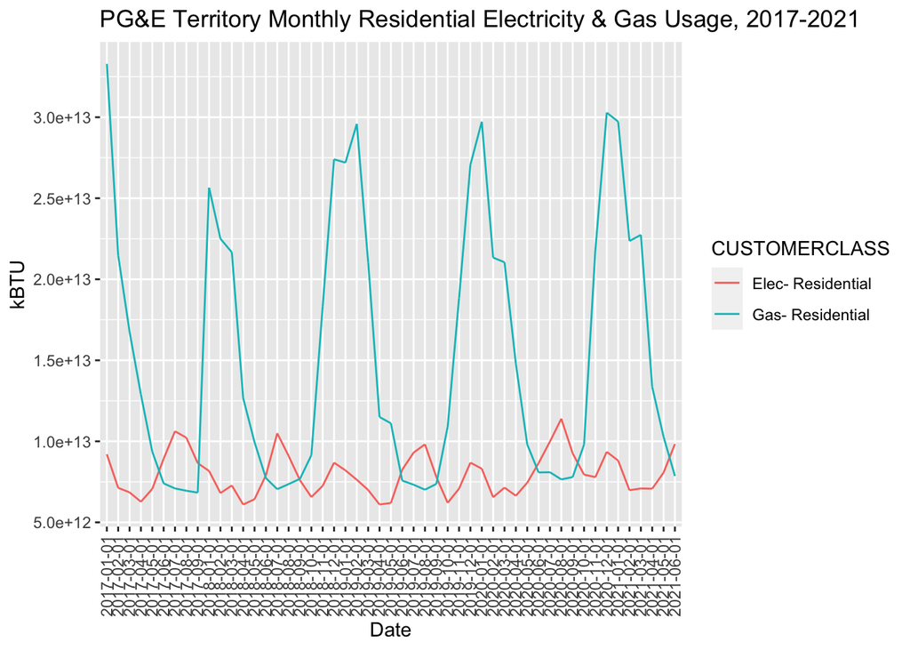

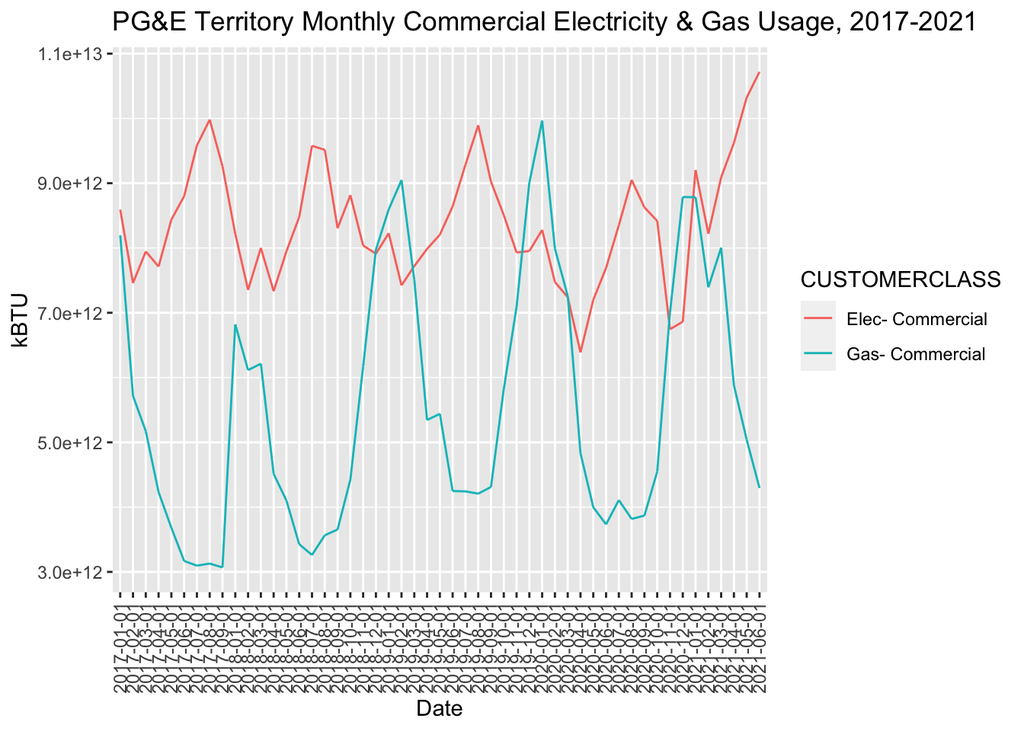

# Zooms in on 2019 and 2020 to see the impact of COVID by removing other years and graphing the datasets.

# Graphs the data for the COVID time period (2019-2020).

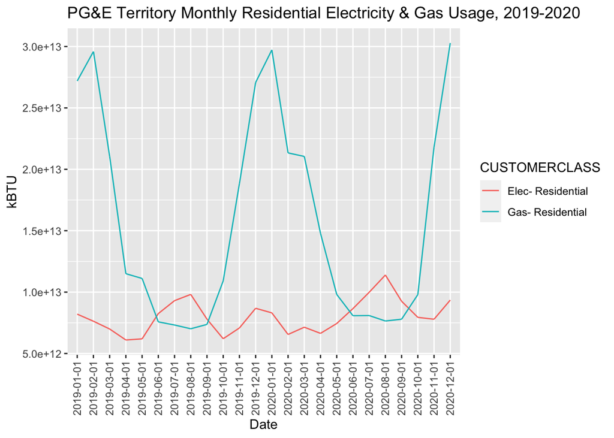

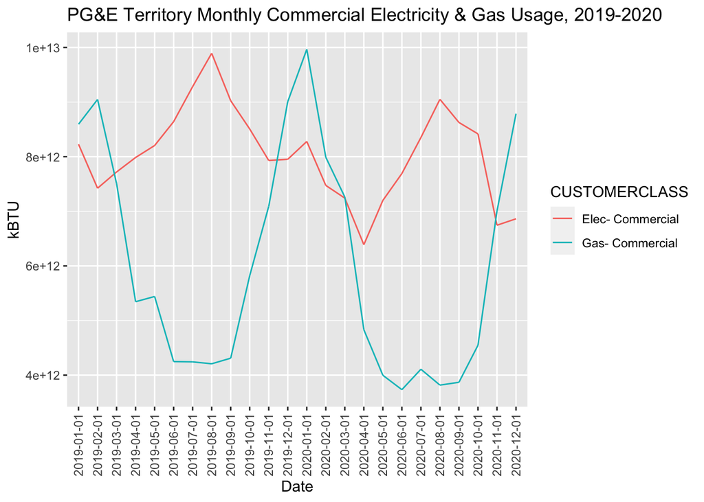

# I understand that I could combine the individual adjustments for each dataset into one line of code given the %>% technique; however, at my current level of coding, it makes more sense for me to keep them separate, in order to more clearly see how each of the parts contributes to the ultimate result. I am happy to change this in the future! Thank you.

# I also would like my x-axises to look more clean, without overlappings, but was not sure how to fix this cosmetic concern. Is there a way to show every other label or every sixth label? I did some Googling but could not find a viable solution. I’d love to learn! Thank you.

# Notable observation on changes potentially due to COVID-19 pandemic: Considering the pandemic and the way that it impacted people’s lives, I would have expected the residential energy use to increase once lockdown began duue to more time spent at home. On the other side of the coin, I would have hypothesized that commercial energy would decrease with less and less industry activity in most commercial domains.However, my data does not seem to reflect this. According to my graphs, gas fluctuatuions in both residential and commercial settings peak in the winter months and dip in the summer, likely due to heating homes. COVID did not appear to impact these numbers or this trend greatly. In terms of electricity usage, residentially, the kBTU values go up and down over the months. They do seem to increase after March 2019 for a few months and peak a second time in August of 2020. This could correspond with increases in infection and more time spent at home but, from what I remember, the waves of electricity use do not match up with the most extreme COVID periods. Commercially, the trends in electricity mirror those in the residential sector, which does not make sense to me as I would predict a decrease here. I am beginning to wonder if my datasets were not manipulated properly!

# Key assumptions or caveats in my analysis: For my analysis, I defined COVID-19 as beginning in March 2019 (2019/03/01) and running through the 2020 year until December (2020/12/01). This may not be in direct correspondance with infection rates and lockdown measures.